# Taller III. Gestión Presupuestaria

Sebastian Freille

Universidad Nacional de Córdoba

# **El sector público: dimensiones y aproximaciones**

## Dimensiones del sector público

> Las dimensiones más relevantes alrededor de la discusión del rol del Estado en la economía pueden resumirse en las siguientes

¿CUÁNTO GASTA/RECAUDA?

→

TAMAÑO

¿EN QUÉ GASTA/RECAUDA?

→

ESTRUCTURA

¿CÓMO EVOLUCIONAN SUS GASTOS/RECURSOS?

→

EVOLUCIÓN

## Tamaño

- Existen múltiples formas de calcular el tamaño del sector público. Algunas de las mas usadas son:
  1. Gasto público (% PBI)
  2. Recaudación total (% PBI)
  3. Cantidad de empleados públicos (% cantidad de empleados totales)
  4. Consumo público (excluye transferencias) (% PBI)
  5. Transferencias y subsidios (% PBI)
  6. Resultado del sector público (% PBI)
- Ninguna es por si sóla suficiente para ser concluyentes pero son útiles individualmente para comparar en el tiempo

## Tamaño (cont.)

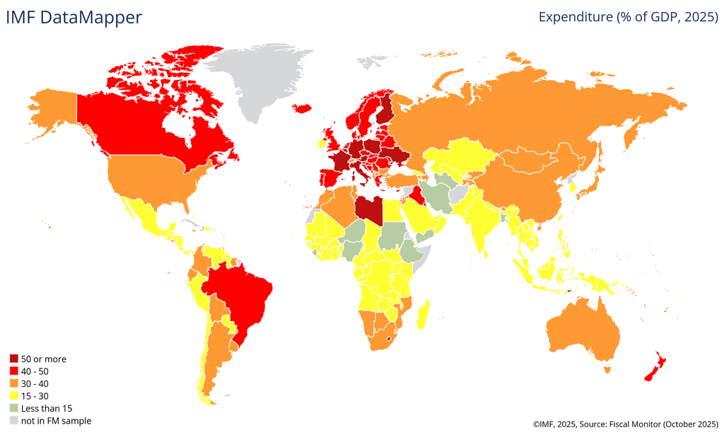

Gasto total del gobierno general como porcentaje del PBI

## Tamaño (cont.)

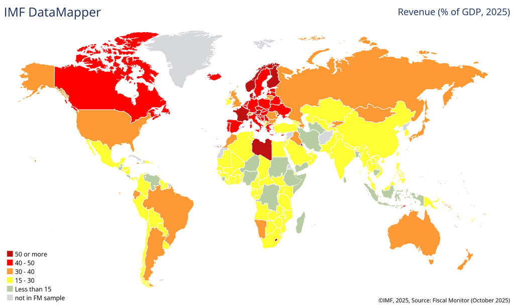

Recaudación total del gobierno general como porcentaje del PBI

## Tamaño (cont.)

[figure not shown]

## Estructura (cont.)

- OECD (1999) provee una clasificación de categorías de gastos públicos
  - servicios públicos generales
  - defensa
  - orden público y seguridad
  - protección ambiental
  - vivienda y comunidad
  - salud
  - educación
  - protección social

## Estructura (cont.)

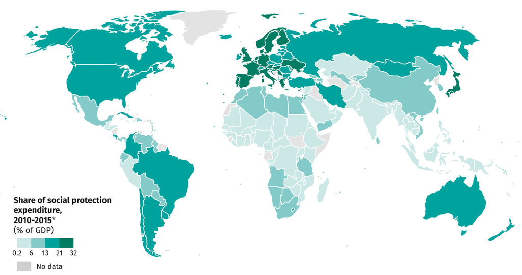

Gasto en protección social como porcentaje del PBI

## Estructura (cont.)

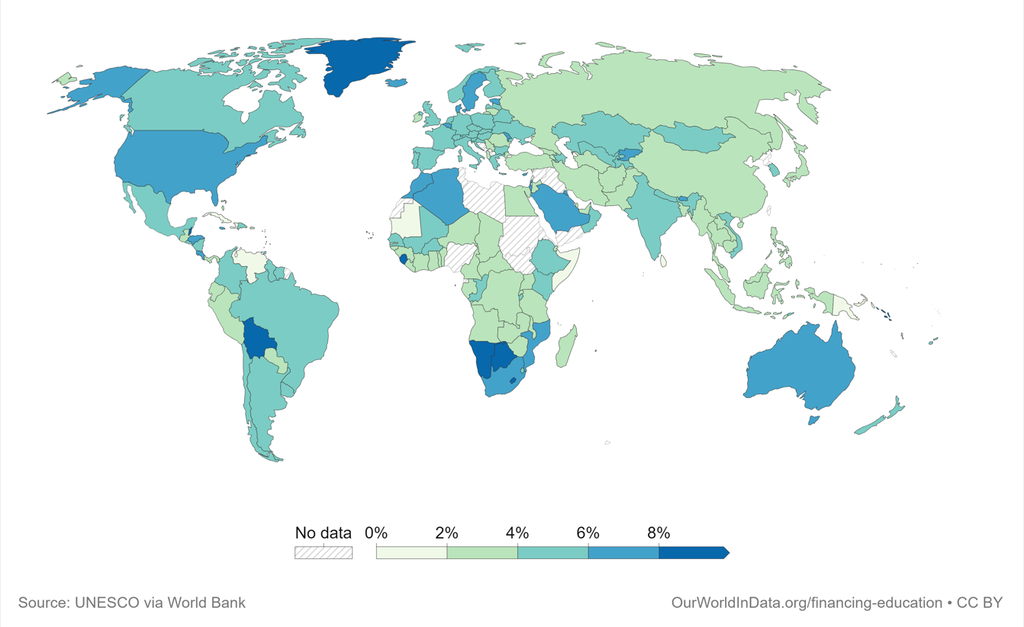

Gasto en educación (todos los niveles) como porcentaje del PBI

## Estructura (cont.)

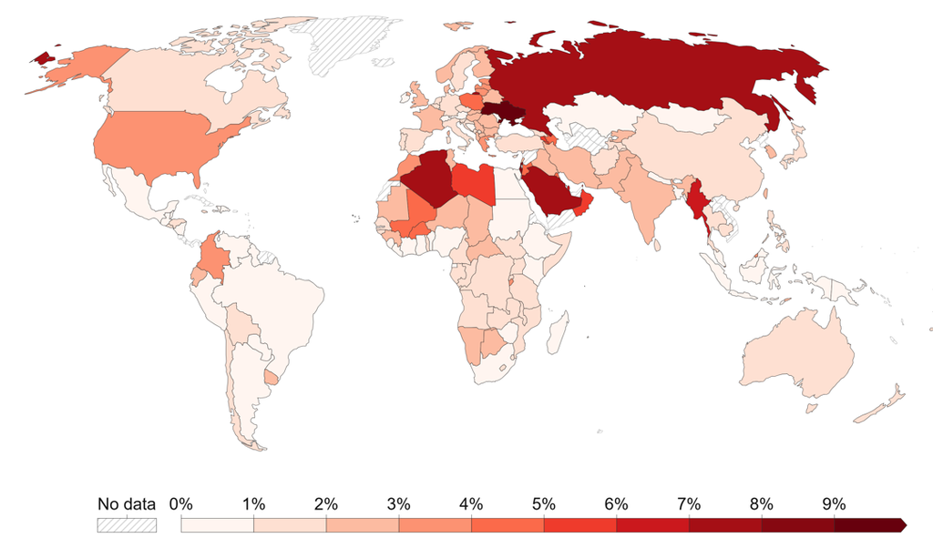

Gasto militar como porcentaje del PBI. Fuente: Stockholm International Peace Research Institute (2025)

## Estructura (cont.)

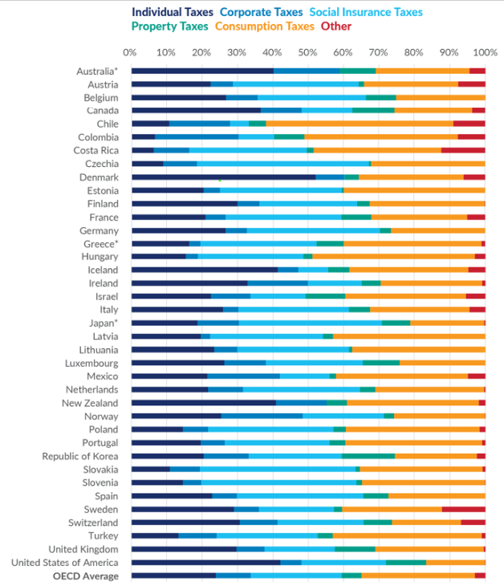

## Evolución

- Si bien el tamaño y la estructura del sector público nos brindan una caracterización bastante detallada del sector público en una economía, resulta incompleto si uno quiere hacer análisis longitudinales (temporales)
  - foto (tamaño y composición) versus película (evolución)
- Es importante el período de evolución de las variables
  - idealmente tomar el período más largo y amplio posible para poder ver tendencias de largo plazo

## Evolución (cont.)

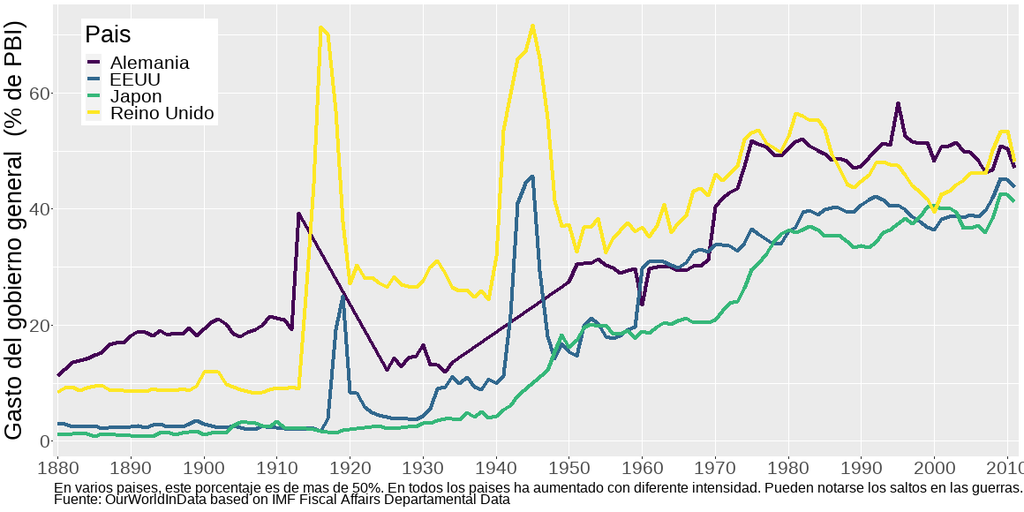

Evolución gasto total del gobierno general como porcentaje del PBI - Países desarrollados

## Evolución (cont.)

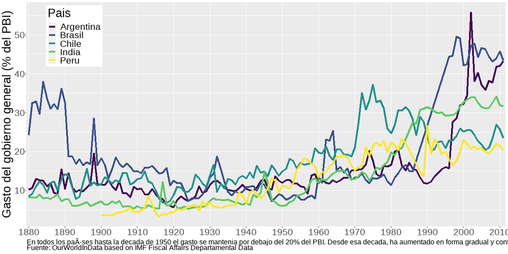

Evolución gasto total del gobierno general como porcentaje del PBI - Países en desarrollo

## Evolución (cont.)

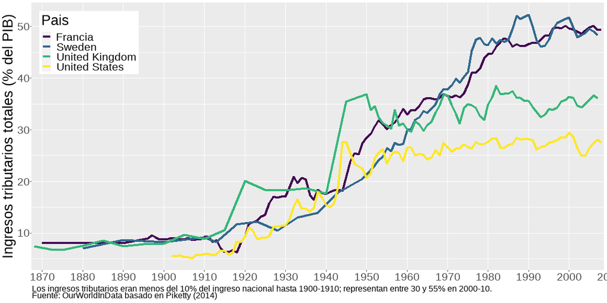

## Evolución (cont.)

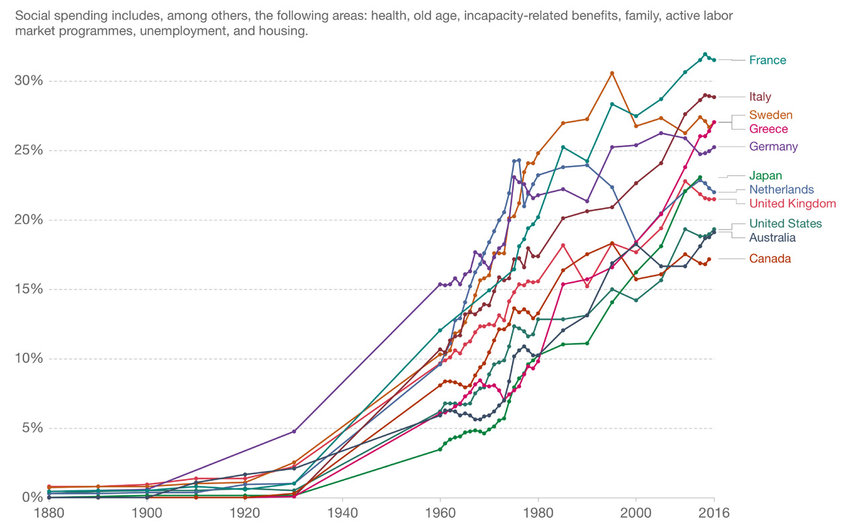

# **¿Y por casa cómo andamos?**

## Tendencias de gasto público

[interactive chart not shown]

## Tendencias del gasto público (cont.)

- Tendencia secular al **crecimiento del gasto público de todos los niveles**
  - diferencias en nivel y variabilidad
    - **nivel provincial crece a mayor tasa que otros niveles**
- Gasto público de **nivel provincial mucha menor dispersión que el nivel nacional** $\longrightarrow$ probablemente refleje mayor poderío y estabilidad política en nivel subnacional
  - producto de reglas institucionales –sistema de pluralidad, menor *accountability*, límites a la reelección.

## Tendencias del gasto público (cont.)

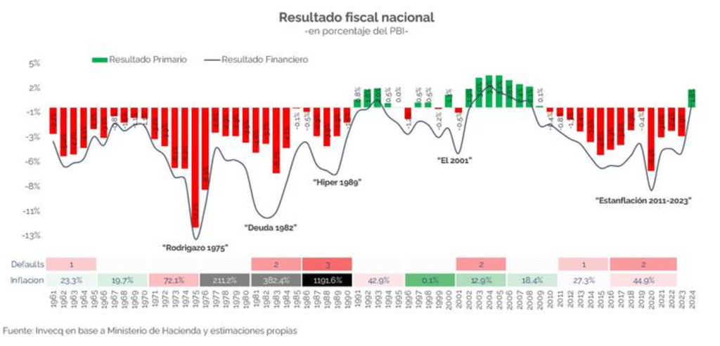

## Financiamiento de gobiernos provinciales

- En su conjunto, los gobiernos provinciales tienen una **alta dependencia financiera del gobierno nacional** en torno al 48%
  - pero la **media esconde ciertas heterogeneidades** –i.e mientras que los recursos propios (ROP) de las provincias grandes (PBA, Córdoba, y Santa Fe) y las patagónicas representan más del 50% del total de sus recursos, para las provincias del NOA y NEA este porcentaje es menos del 25%
- La composición de los ROP es incluso un tema más delicado $\longrightarrow$ provincias deben **recurrir cada vez más a impuestos más distorsivos e inequitativos**

## ROP: Dependencia estructural de IIBB

[interactive chart not shown]

## ROP: Dependencia estructural de IIBB (cont.)

- En promedio las provincias argentinas pasan de 57.32% en 1984 a 83.18% en 2024
  - se produce una **sustitución gradual de impuestos patrimoniales (directos) por impuestos a las ventas (indirectos)**
  - relativa homogeneidad provincial con notable excepción de Tierra del Fuego en que la participación de IIBB se mantiene debajo de 60% –principalmente regalías y derechos hidrocarburífero; y otros fondos de financiamiento específicos

## ROP: Dependencia estructural de IIBB (cont.)

[interactive chart not shown]

## Economía política del presupuesto

- Por razones de diseño institucional y de funcionamiento, el federalismo existente en Argentina tiende a generar una suerte de tormenta perfecta cuando existe una alta competencia y fragmentación electoral

> Ejecutivo nacional con bajo caudal electoral, legislativo nacional fragmentado y opositor, gobernadores provinciales con alto apoyo electoral

## Economía política del presupuesto (cont.)

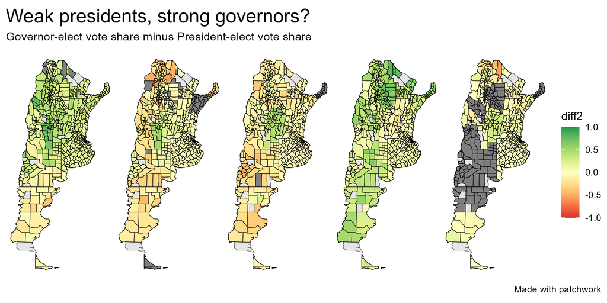

Poderío electoral relativo

# **Roles y funciones del Estado**

## Funciones del Estado

> El Estado realiza una gran cantidad de actividades en la vida económica. Desde la economía del sector público, se las suele dividir en las siguientes

ASIGNACIÓN

→

Construcción de espacio verde, alumbrado público, recolección de residuos

DISTRIBUCIÓN

→

Cobra impuestos progresivos, brinda subsidios, transferencias y ayuda

ESTABILIZACIÓN

→

Utiliza política fiscal, monetaria, cambiaria, y regulatoria para suavizar fluctuaciones de la actividad económica

## Funciones del Estado (cont.)

- ¿Cómo se expresan estas funciones del Estado en la práctica? ¿Cómo sabemos la ponderación que los diferentes gobiernos asignan a las diferentes funciones?
  - mirando la política de gastos y la política tributaria

> En muchas situaciones, el gobierno utiliza una cierta política pública para realizar más de una de estas funciones al mismo tiempo. Ejemplo: 1) gobierno puede hacer función redistribución a través de función asignación –i.e. recorta gastos en planta administrativa y aumenta gastos en educación y salud pública; 2) gobierno puede hacer función estabilización y redistribución al mismo tiempo –i.e. aumenta la AUH para estabilizar y estimular demanda (vía consumo)

## Funciones del Estado (cont.)

- A diferencia de los agentes privados que interactúan y toman decisiones a través del mecanismo de mercado, el **gobierno toma decisiones (asignación, redistribución y estabilización) a través del mecanismo político**
- Este mecanismo y proceso es un **proceso eminentemente político**
  - intervienen múltiples actores –políticos, burócratas, empresarios, organizaciones de la sociedad civil, ciudadanos
  - el combo de asignación, redistribución y estabilización alcanzado *debería* reflejar en mayor o menor medida los **acuerdos (y desacuerdos) resultantes de este proceso**.

## Funciones del Estado (cont.)

> Así como el mecanismo de mercado brinda señales (precios, cantidades) para la asignación de recursos privados, el mecanismo político agrega colectivamente las preferencias de los ciudadanos para identificar el tamaño, la estructura y la evolución de la participación del Estado en la economía
- La principal herramienta a través de la cual el Estado realiza esto es
  - **el presupuesto público**

# **El Presupuesto público**

## Conceptualización

> **Enfoque tradicional.** El Presupuesto es la expresión, en términos financieros, de lo que el gobierno pretende llevar a cabo en un período determinado, por regla general, un año

> **Enfoque moderno.** El Presupuesto es un instrumento útil para la programación económica y social, de gobierno, de administración y necesariamente un acto legislativo.

## Importancia

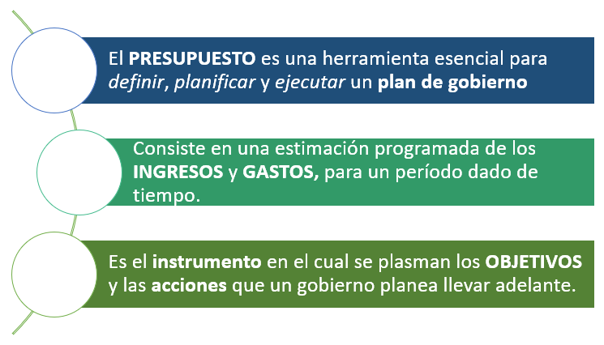

Importancia y utilidad del presupuesto

## Sistema de administración financiera

- El presupuesto público forma parte del sistema presupuetario que a su vez es uno de los subsistemas del sistema de administración financiera del Estado
- Ley 24156 (1992) de Administración Financiera y de los Sistemas de Control del Sector Público Nacional brinda el paraguas legal de todo el sistema
- A su vez la Constitución Nacional varios artículos refieren a las diferentes potestades y responsabilidades de los diferentes poderes republicanos y otros organismos públicos
  - el curso se enfoca principalmente en el sistema presupuestario y específicamente en el presupuesto público

## Sistema de administración financiera (cont.)

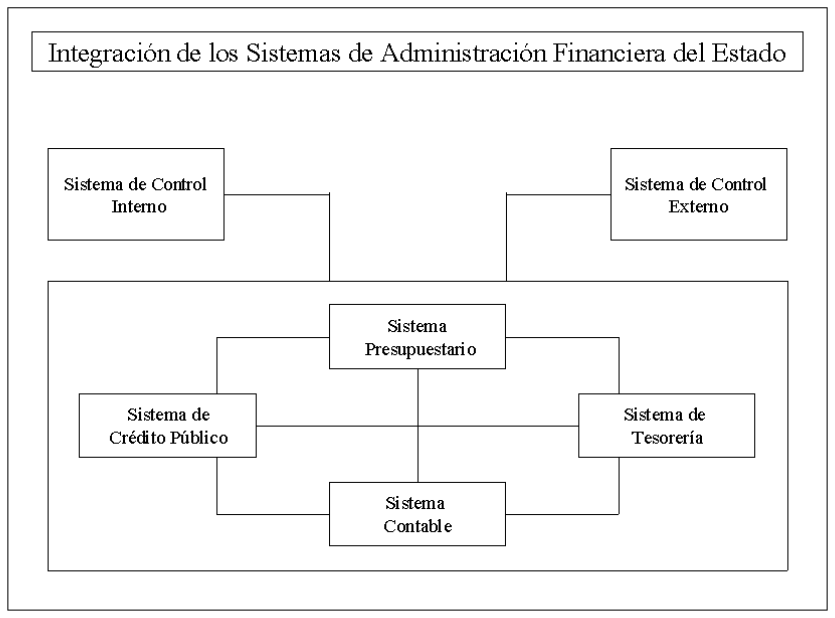

Sistema de administración financiera del Estado

## Roles

1. Como instrumento de gobierno $\longrightarrow$ el más importante de todos
2. Como instrumento de programación económica y social $\longrightarrow$ acciones económicas de mediano plazo se elaboran en términos de agregados macroeconómicos. Operativiza las orientaciones de la política económica
3. Como instrumento de administración $\longrightarrow$ ejecución del presupuesto involucra división de trabajo entre diferentes unidades
4. Como acto legislativo $\longrightarrow$ aprobación del presupuesto constituye un acto legislativo indispensable
5. Como documento $\longrightarrow$ se expresa en un documento -analítico, sintético, resumen.

## Ciclo Presupuestario

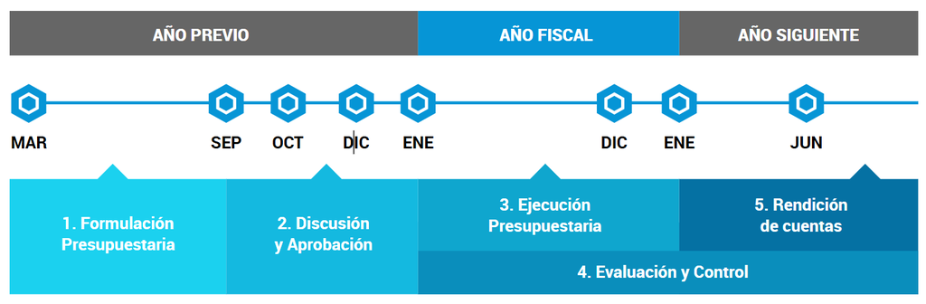

El ciclo prespuestario